# Sensor Fusion Project

## Task 1

- (a) Task 1a consists of understanding what the data represents. That will be covered in the report, and is not detailed in this Jupyter notebook.
- (b) Task 1b involves determining the bias and variance of the gyroscope.

The sensor model for the gyroscope is in the form of $\mathbf{y} = \mathbf{G} \mathbf{\omega} + \mathbf{b} + \mathbf{r}$, where each individual measurement $\mathbf{y}_n \in \mathbb{R}^{3}$.

I have used **Dataset 2** for the project. There's a variable named `datasetNumber` that represents which dataset was used for the assignment.

```python
# Imports
import numpy as np
import pandas as pd
import matplotlib.pyplot as plt
from scipy.signal import resample
%matplotlib inline

import matplotlib_inline
matplotlib_inline.backend_inline.set_matplotlib_formats('retina')
plt.rcParams['figure.figsize'] = [10, 8]
# from IPython.display import set_matplotlib_formats
# set_matplotlib_formats('retina')
```

```python
# data
datasetNumber = 2  # DATASET NUMBER
pathToDataset = f'part1datasets/dataset{datasetNumber}/data/task1/imu_reading_task1.csv'

# i added this line in the CSV file to make the indexing easier
# timestamp,ax,ay,az,roll,pitch,wx,wy,wz,mx,my,mz
```

```python
task1Dataset = pd.read_csv(pathToDataset)
# print(task1Dataset.keys())
```

```python
# extracting the data into numpy arrays
t = task1Dataset['timestamp'].to_numpy()
t = t - t[0] # this goes from absolute time from epoch to relative time
wx, wy, wz = (task1Dataset[i].to_numpy() for i in ('wx', 'wy', 'wz'))
```

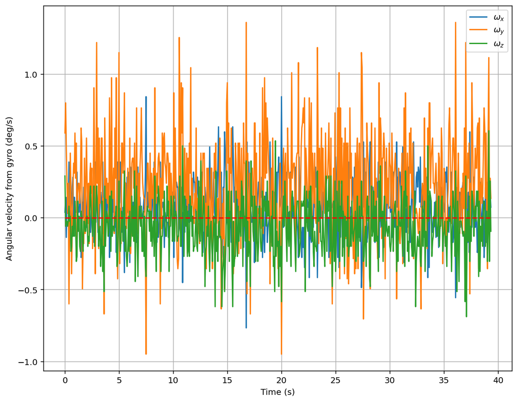

```python
# Plotting the extracted data
plt.figure()
plt.plot(t, wx, label='$\omega_x$')
plt.plot(t, wy, label='$\omega_y$')
plt.plot(t, wz, label='$\omega_z$')
plt.plot([t[0], t[-1]], [0, 0], 'r--')
plt.xlabel('Time (s)')
plt.ylabel('Angular velocity from gyro (deg/s)')
plt.legend()
plt.grid()
plt.show()
```

### Finding the bias and variance

**Bias**: The average along each axis is taken and subtracted from zero.  
**Variance**: The variance along each axis

```python
# bias
bx, by, bz = np.mean(wx), np.mean(wy), np.mean(wz)
# variance
sigma_x, sigma_y, sigma_z = np.var(wx), np.var(wy), np.var(wz)
```

```python
# print the results
print(f'The bias of the gyroscope is -- b_x: {bx}, b_y: {by}, b_z: {bz}')
print(f'The variance of the gyroscope is -- w_x: {sigma_x}, w_y: {sigma_y}, w_z: {sigma_z}')
```

```
The bias of the gyroscope is -- b_x: 0.08586055555555555, b_y: 0.2221088888888889, b_z: -0.06465555555555555
The variance of the gyroscope is -- w_x: 0.037367024691358025, w_y: 0.12977254320987655, w_z: 0.03734869135802469
```